# Çiçek Veri Seti Analizi

**Hazırlayan**:Rumeysa Kırımlı

**Ders**: Veri Analizinde Bilgisayar Programlama

**Tarih**: 08/06/2026

### Özet:

Bu çalışmada çiçek veri seti üzerinde tanımsal istatistikler ve veri görselleştirme analizleri yaptım. Çiçek türleri, boy uzunlukları ve koku özellikleri inceleyip, grafikler ve istatistiksel analizler yardımıyla veri setindeki dağılımlar değerlendirdim.

### Analiz Amacı:

Bu çalışmanın amacı çiçek türleri arasındaki boy dağılımlarını incelemek, koku ve boy özellikleri arasındaki ilişkileri görselleştirmek ve veri setinin genel yapısını anlamaktır.

### Analiz Yöntemi:

- Bu çalışmada veri analizi süreci Python programlama dili kullanılarak gerçekleştirilmiştir.
- Analizde veri keşfi (EDA), tanımsal istatistikler, veri görselleştirme ve gruplama analizleri kullanılmıştır.
- Pandas ile veri işleme, Matplotlib ve Seaborn ile statik görselleştirme, Plotly ile etkileşimli görselleştirme yapılmıştır.
- Amaç veri setinin yapısını anlamak ve değişkenler arasındaki ilişkileri incelemektir.

## Veri Seti Hakkında:

Veri Özeti Tablosu:

- Toplam gözlem: 10.000
- Değişken sayısı: 4
- Sayısal değişken: 1 (height_cm)
- Kategorik değişken: 3 (species, size, fragrance)

**Değişkenler:**

- species: Çiçek türü
- size: Çiçeğin boyut kategorisi
- fragrance: Koku seviyesi
- height_cm: Çiçek boyu (cm)

Veri setinde eksik değer bulunmamaktadır.

```python
import pandas as pd

df = pd.read_csv("flowers.csv")
```

```python
df.shape
```

```
(10000, 4)
```

```python
df.columns.tolist()
```

```
['species', 'size', 'fragrance', 'height_cm']
```

## Veri Temizliği:

```python
df.isnull().sum()
```

```
species      0
size         0
fragrance    0
height_cm    0
dtype: int64
```

**YORUM:**

- Veri setindeki eksik değerler kontrol edilmiş ve eksik veri bulunmadığı görülmüştür. Bu nedenle ek veri temizleme işlemi uygulanmamıştır.

```python
df["height_category"] = pd.cut(df["height_cm"], bins=3)

df.head()
```

|  | species | size | fragrance | height_cm | height_category |
| --- | --- | --- | --- | --- | --- |
| 0 | rose | medium | mild | 48.55 | (29.92, 86.717] |
| 1 | shoeblack plant | medium | mild | 147.07 | (143.343, 199.97] |
| 2 | shoeblack plant | medium | none | 102.93 | (86.717, 143.343] |
| 3 | hibiscus | large | none | 184.00 | (143.343, 199.97] |
| 4 | shoeblack plant | large | mild | 83.07 | (29.92, 86.717] |

```python
import pandas as pd
import numpy as np
import matplotlib.pyplot as plt
import seaborn as sns
import plotly.express as px
import plotly.io as pio

pio.renderers.default = "notebook_connected"

sns.set_style("whitegrid")
plt.rcParams["figure.figsize"] = (10,5)
```

```python
import pandas as pd

df = pd.read_csv("flowers.csv")

df.head()
```

|  | species | size | fragrance | height_cm |
| --- | --- | --- | --- | --- |
| 0 | rose | medium | mild | 48.55 |
| 1 | shoeblack plant | medium | mild | 147.07 |
| 2 | shoeblack plant | medium | none | 102.93 |
| 3 | hibiscus | large | none | 184.00 |
| 4 | shoeblack plant | large | mild | 83.07 |

## Tanımsal İstatistikler:

```python
df.info()
```

```
<class 'pandas.DataFrame'>
RangeIndex: 10000 entries, 0 to 9999
Data columns (total 4 columns):
 #   Column     Non-Null Count  Dtype
---  ------     --------------  -----
 0   species    10000 non-null  str
 1   size       10000 non-null  str
 2   fragrance  10000 non-null  str
 3   height_cm  10000 non-null  float64
dtypes: float64(1), str(3)
memory usage: 312.6 KB
```

```python
df.describe()
```

|  | height_cm |
| --- | --- |
| count | 10000.000000 |
| mean | 104.873938 |
| std | 43.635191 |
| min | 30.090000 |
| 25% | 69.307500 |
| 50% | 100.510000 |
| 75% | 137.022500 |
| max | 199.970000 |

```python
df["species"].value_counts()
```

```
species
rose               3345
shoeblack plant    3337
hibiscus           3318
Name: count, dtype: int64
```

```python
df["fragrance"].value_counts()
```

```
fragrance
none      5003
mild      3327
strong    1670
Name: count, dtype: int64
```

## Grafik Analizleri:

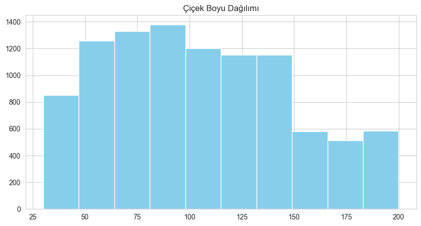

```python
import matplotlib.pyplot as plt

df["height_cm"].hist(color="skyblue")
plt.title("Çiçek Boyu Dağılımı")
plt.show()
```

**Yorum:**

- Histogram grafiğine göre çiçek boyları yaklaşık 30 cm ile 200 cm arasında değişmektedir.
- Verilerin büyük kısmı 70 cm ile 140 cm aralığında yoğunlaşmıştır.
- Çok kısa ve çok uzun çiçeklerin veri setinde daha az bulunduğu görülmektedir kısacası dağılım orta değerlerde kümelenme göstermektedir.

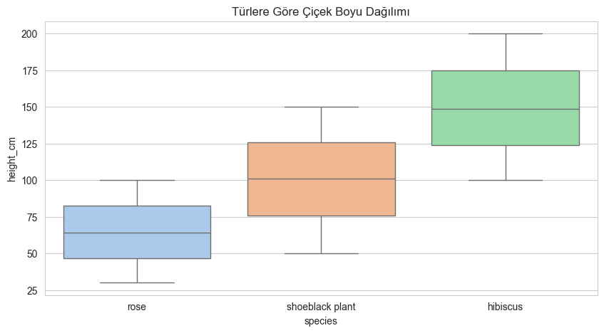

```python
sns.boxplot(data=df, x="species", y="height_cm", hue="species", palette="pastel", legend=False)
plt.title("Türlere Göre Çiçek Boyu Dağılımı")
plt.show()
```

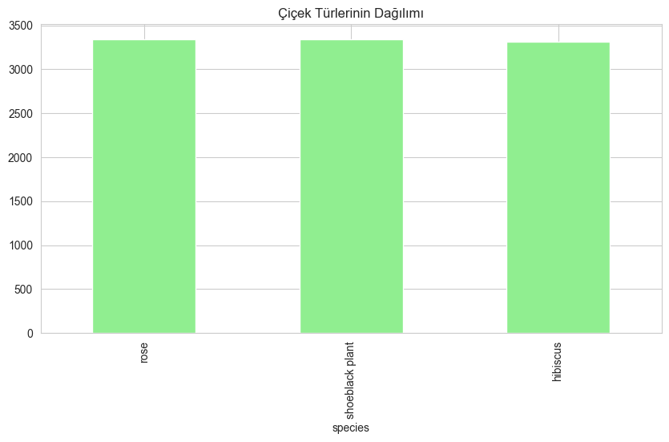

```python
df["species"].value_counts().plot(kind="bar", color="lightgreen")
plt.title("Çiçek Türlerinin Dağılımı")
plt.show()
```

**Yorum:**

- Türlerin veri setindeki dağılımı birbirine oldukça yakındır.
- Rose türü en fazla gözleme sahiptir.
- Veri seti genel olarak dengeli bir dağılım göstermektedir.

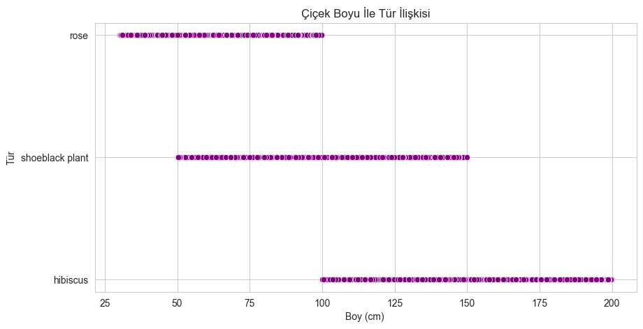

```python
sns.scatterplot(data=df, x="height_cm", y="species", color="purple")
plt.title("Çiçek Boyu İle Tür İlişkisi")
plt.xlabel("Boy (cm) ")
plt.ylabel("Tür")
plt.show()
```

**Yorum:**

- Çiçek boyu türlere göre farklılık göstermektedir.
- Rose türü daha düşük boy aralıklarında yoğunlaşmıştır.
- Hibiscus daha geniş bir dağılıma sahiptir.

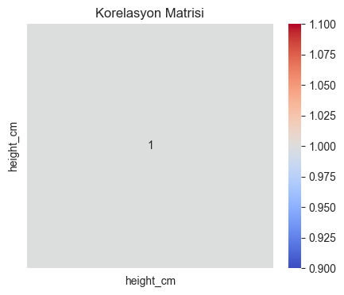

```python
import seaborn as sns
import matplotlib.pyplot as plt

# Korelasyon matrisi
corr = df[["height_cm"]].corr()

plt.figure(figsize=(5,4))
sns.heatmap(corr, annot=True, cmap="coolwarm")
plt.title("Korelasyon Matrisi")
plt.show()
```

**Yorum:**

- Veri setinde yalnızca height_cm sayısal değişkeni bulunduğu için korelasyon analizi sınırlıdır
- Heatmap grafiğinde yalnızca sayısal değişkenler arasındaki korelasyon gösterilmektedir.
- Korelasyon analizi yalnızca height_cm üzerinden yapılabildiği için anlamlı korelasyon ilişkisi gözlenmemiştir.
- Bu nedenle detaylı bir korelasyon analizi yapılamamaktadır.

```python
import plotly.express as px
import plotly.io as pio

pio.renderers.default = "notebook_connected"
```

```python
import plotly.express as px

fig = px.scatter(df, x="height_cm", y="species", color="fragrance")

fig.show()

fig.write_html("bonus_graph.html")
```

[interactive chart not shown]

**Yorum:**

- Etkileşimli scatter grafiği sayesinde çiçek boyu, tür ve koku özellikleri birlikte incelenebilmektedir.
- None koku kategorisinin veri setinde daha yoğun olduğu görülmektedir.
- Grafik kullanıcıya yakınlaştırma ve detay inceleme imkanı sağlamaktadır.

```python
fig = px.box(
    df,
    x="species",
    y="height_cm",
    title="Türlere Göre Boy Dağılımı"
)

fig.show()
```

[interactive chart not shown]

**Yorum:**

- Etkileşimli boxplot grafiği türlere göre boy dağılımlarını daha detaylı göstermektedir.
- Hibiscus türünde maksimum boy değerlerinin daha yüksek olduğu dikkat çekmektedir.
- Boxplot grafiği dağılım farklılıklarını daha anlaşılır hale getirmektedir.

## BULGULAR VE SONUÇLAR :

**Genel Sonuç:** Yapılan analizler sonucunda çiçek türleri arasında boy dağılımı açısından belirgin farklılıklar olduğu gözlemlenmiştir. Grafikler ve tanımsal istatistikler veri setinin genel yapısını anlamada faydalı olmuştur.

## Ek Analizler:

```python
df.groupby("species")["height_cm"].agg(["mean","min","max","std"])
```

| species | mean | min | max | std |
| --- | --- | --- | --- | --- |
| hibiscus | 149.475139 | 100.05 | 199.97 | 29.219335 |
| rose | 64.701390 | 30.09 | 100.00 | 20.320629 |
| shoeblack plant | 100.795541 | 50.02 | 149.87 | 28.823051 |

**Yorum**: Türlere göre ortalama, minimum, maksimum ve standart sapma değerleri incelendiğinde Hibiscus türünün hem daha yüksek ortalamaya hem de daha geniş bir dağılıma sahip olduğu görülmektedir.

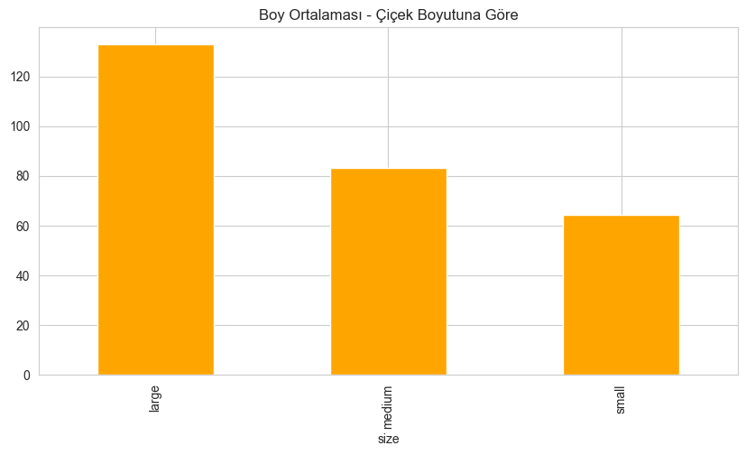

```python
df.groupby("size")["height_cm"].mean().plot(kind="bar", color="orange")
plt.title("Boy Ortalaması - Çiçek Boyutuna Göre")
plt.show()
```

**Yorum**: Çiçek boyut kategorilerine göre ortalama boy değerleri incelendiğinde farklılıklar gözlemlenmektedir.

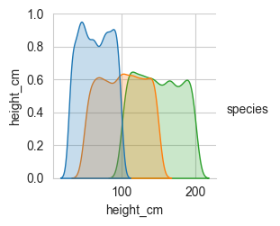

```python
sns.pairplot(df, hue="species")
plt.show()
```

**Yorum**:Tür değişkenine göre değişkenler arasındaki ilişkiler görselleştirilmiştir.

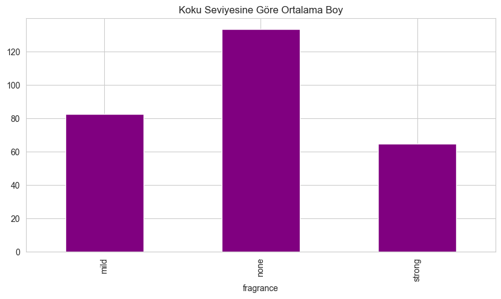

```python
df.groupby("fragrance")["height_cm"].mean().plot(kind="bar", color="purple")
plt.title("Koku Seviyesine Göre Ortalama Boy")
plt.show()
```

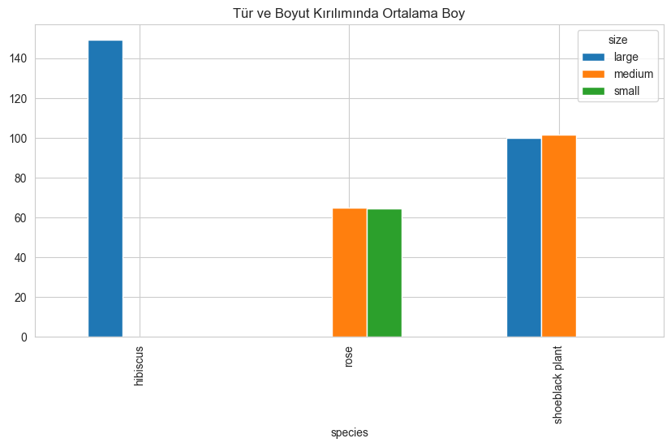

```python
df.groupby(["species", "size"])["height_cm"].mean().unstack().plot(kind="bar")
plt.title("Tür ve Boyut Kırılımında Ortalama Boy")
plt.show()
```

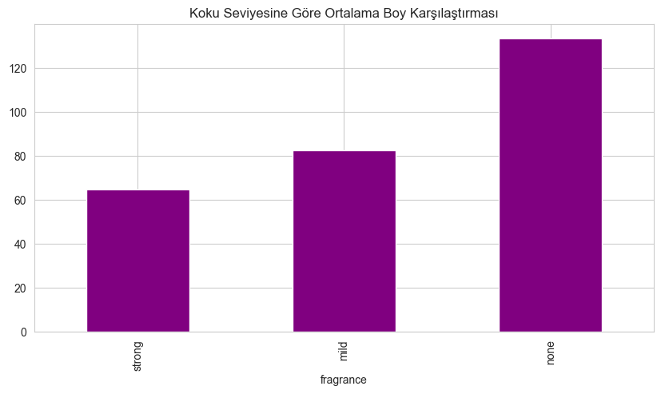

```python
df.groupby("fragrance")["height_cm"].mean().sort_values().plot(kind="bar", color="purple")
plt.title("Koku Seviyesine Göre Ortalama Boy Karşılaştırması")
plt.show()
```

### Genel Sonuç:

- Bu çalışma veri analizi sürecinde veri keşfi, görselleştirme ve yorumlama adımlarının birlikte kullanılmasının önemini göstermiştir.
- Veri analizi, görselleştirme teknikleri ile desteklendiğinde veri setinin yapısı daha anlaşılır hale gelmiştir.

Tüm analizler Python (Pandas, Seaborn, Matplotlib, Plotly) kullanılarak gerçekleştirilmiştir.

```python
plt.tight_layout()
```

```python
!python -m nbconvert --to html analysis.ipynb --output FINAL_ODEV.html
```

```
[NbConvertApp] Converting notebook analysis.ipynb to html
[NbConvertApp] WARNING | Alternative text is missing on 10 image(s).
[NbConvertApp] Writing 1049991 bytes to FINAL_ODEV.html
```

```python
!python -m nbconvert --to script analysis.ipynb
```

```
[NbConvertApp] Converting notebook analysis.ipynb to script
[NbConvertApp] Writing 8807 bytes to analysis.py
```